# Effect Size

ChatGPT 4o

2025-01-21

## 1 起源

效应量（Effect Size）是由心理学家Jacob Cohen在20世纪60年代提出的，用于衡量研究中两个组之间的差异或某种效应的大小。效应量的概念使得研究人员可以从统计显著性中分离出效应的实际意义，特别是在样本量较大的情况下，可以更好地理解研究结果的实际影响。如今，效应量广泛应用于心理学、医学、教育学等多个领域，以评估实验处理的影响。

## 2 原理

效应量是用于衡量两个变量之间关系的强度或某种效应的大小的指标，是独立于样本量的统计量，可以帮助更好地解释研究结果的实际意义。效应量的计算通常根据不同的研究设计和测量尺度而不同，以下是常见效应量的计算公式：

### 不同效应量的计算公式

- **Cohen’s d**：用于评估两个独立样本均值之间的差异。
  $$d = \frac{\mu_1 - \mu_2}{s_p}$$
  其中，$\mu_1$ 和 $\mu_2$ 分别为两组的均值，$s_p$ 为合并标准差：
  $$s_p = \sqrt{\frac{(n_1 - 1)s_1^2 + (n_2 - 1)s_2^2}{n_1 + n_2 - 2}}$$
  其中，$s_1$ 和 $s_2$ 为两组的标准差，$n_1$ 和 $n_2$ 为两组的样本量。
- **Cohen’s f**：用于衡量方差分析（ANOVA）中组间效应的大小。
  $$f = \frac{\sigma_\text{between}}{\sigma_\text{within}}$$
  其中，$\sigma_\text{between}$ 为组间方差，$\sigma_\text{within}$ 为组内方差。
- **Pearson’s r**：用于衡量两个连续变量之间的相关性。
  $$r = \frac{\sum (X - \bar{X})(Y - \bar{Y})}{\sqrt{\sum (X - \bar{X})^2
  \sum (Y - \bar{Y})^2}}$$
  其中，$X$ 和 $Y$ 分别为两个变量的观测值，$\bar{X}$ 和 $\bar{Y}$ 为两个变量的均值。
- **Eta Squared ($\eta^2$**)：用于衡量方差分析中处理变量对总变异的贡献。
  $$\eta^2 = \frac{SS_\text{between}}{SS_\text{total}}$$
  其中，$SS_\text{between}$ 为组间平方和，$SS_\text{total}$ 为总平方和。
- **Odds Ratio (OR)**：用于衡量二分类结果之间的关联。
  $$OR = \frac{(a / b)}{(c / d)}$$
  其中，$a$ 和 $b$ 分别为实验组和对照组的阳性结果数，$c$ 和 $d$ 为阴性结果数。

## 3 适用范围

效应量适用于以下情况：

- **衡量组间差异**：用于评估两个或多个组之间差异的大小，以量化实验处理的效果。
- **相关性分析**：用于评估两个变量之间的相关性，帮助确定变量之间的关系强度。
- **方差分析**：在方差分析中衡量处理效应的大小，帮助解释不同处理对因变量的影响程度。
- **回归分析**：评估预测变量对结果变量的影响大小，量化模型解释变量的贡献。

## 4 应用情境

效应量在多个领域中有广泛的应用，例如：

- **医学和公共卫生**：用于评估治疗效果的大小，如新药治疗组与对照组之间的差异。
- **心理学和教育学**：评估干预措施对实验组和控制组的影响差异，量化心理治疗或教学方法的效果。
- **社会科学**：在社会调查中评估不同群体之间的行为差异和相关性。
- **市场研究**：用于评估营销策略对不同顾客群体的影响程度。

## 5 优缺点

### 优点

- **独立于样本量**：效应量可以独立于样本量衡量效应的大小，避免了过分依赖显著性水平的局限性。
- **解释实际意义**：效应量可以帮助解释研究结果的实际意义，量化效应的大小，使得结果更具可理解性。
- **比较性强**：不同研究之间的效应量可以直接进行比较，帮助合并多个研究的结果，尤其是在Meta分析中。

### 缺点

- **计算复杂**：对于一些效应量的计算较为复杂，尤其是在处理方差分析和多组数据时，需要较高的统计知识。
- **对数据类型的依赖**：不同类型的数据需要不同的效应量计算方法，选择不当可能会导致错误的结论。
- **解释可能存在争议**：效应量的阈值通常是经验性的，如何解释效应量的大小（如小、中、大）可能存在一定的主观性。

## 6 在R中的实现及结果解释

在R中，可以使用`effsize`包或其他统计包计算效应量。以下是一个使用`effsize`包计算Cohen’s d的示例：

```r
# 加载必要的包
# devtools::install_github("ndphillips/yarrr")
library(effsize)

# 示例数据：生成假设的两组数据
group1 <- c(2.3, 3.4, 2.8, 3.6, 2.9)
group2 <- c(3.8, 4.2, 4.0, 4.5, 4.1)

# 计算Cohen's d
d_result <- cohen.d(group1, group2)

# 输出Cohen's d结果
print(d_result)
```

```
##
## Cohen's d
##
## d estimate: -2.748932 (large)
## 95 percent confidence interval:
##      lower      upper
## -4.7827064 -0.7151574
```

```r
summary(d_result)
```

```
##            Length Class   Mode
## method     1      -none-  character
## name       1      -none-  character
## estimate   1      -none-  numeric
## sd         1      -none-  numeric
## conf.int   2      -none-  numeric
## var        1      -none-  numeric
## conf.level 1      -none-  numeric
## magnitude  1      ordered numeric
```

```r
str(d_result)
```

```
## List of 8
##  $ method    : chr "Cohen's d"
##  $ name      : chr "d"
##  $ estimate  : num -2.75
##  $ sd        : num 0.407
##  $ conf.int  : Named num [1:2] -4.783 -0.715
##   ..- attr(*, "names")= chr [1:2] "lower" "upper"
##  $ var       : num 0.778
##  $ conf.level: num 0.95
##  $ magnitude : Ord.factor w/ 4 levels "negligible"<"small"<..: 4
##  - attr(*, "class")= chr "effsize"
```

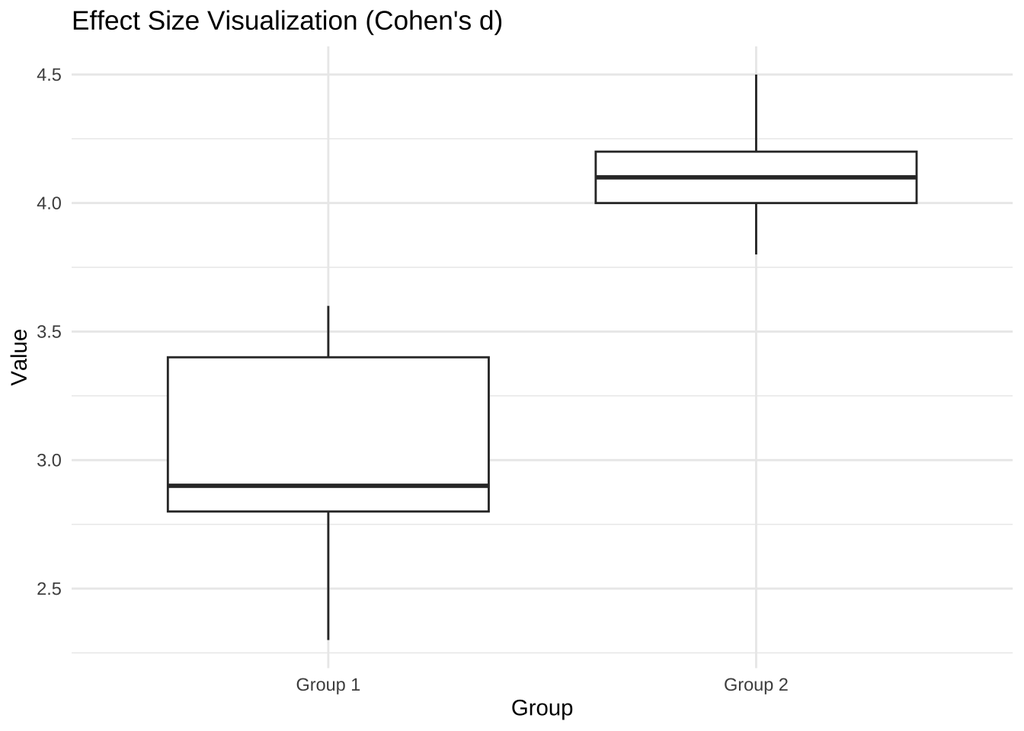

```r
# 绘制效果量分布图
group_data <- data.frame(
  group = rep(c("Group 1", "Group 2"), each = 5),
  value = c(group1, group2)
)

# 使用ggplot2绘制
library(ggplot2)
ggplot(group_data, aes(x = group, y = value)) +
  geom_boxplot() +
  labs(title = "Effect Size Visualization (Cohen's d)", x = "Group", y = "Value") +
  theme_minimal()
```

### 结果解释

- **Cohen’s d结果**：通过`cohen.d()`函数计算Cohen’s d值，用于衡量两组之间的均值差异大小。输出结果中，效应量的大小可以用来解释两组之间的差异是否具有实际意义。
- **效应量可视化**：通过箱线图对两组数据进行可视化，可以直观地展示两组之间的差异，帮助理解效应量的大小和数据的分布情况。

### 结果的可视化

效应量的可视化有助于直观理解两组数据之间的差异。例如，使用箱线图展示两组数据的分布，结合效应量的数值，可以更好地评估效应的大小和实际意义。

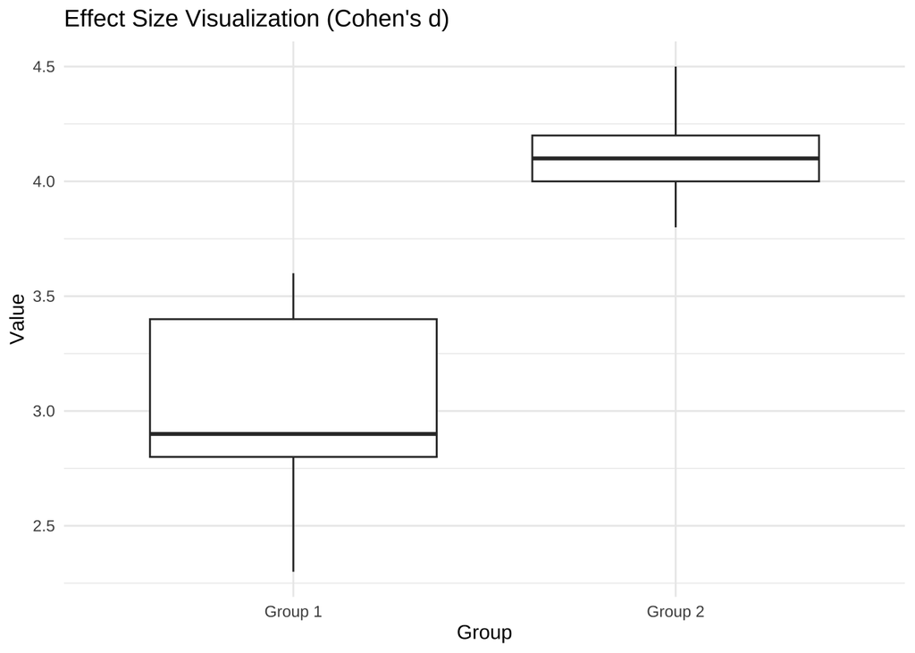

```r
# 使用ggplot2绘制效果量分布图
ggplot(group_data, aes(x = group, y = value)) +
  geom_boxplot() +
  labs(title = "Effect Size Visualization (Cohen's d)", x = "Group", y = "Value") +
  theme_minimal()
```

## 7 小结

- 效应量是一种用于衡量实验效应大小的统计量，独立于样本量，广泛应用于医学、心理学、教育学等领域。
- 常见的效应量包括Cohen’s d、Pearson’s r、Eta Squared等，不同效应量适用于不同类型的研究设计。
- 具有独立于样本量、便于解释实际意义和比较性强的优点，但计算复杂性和对数据类型的依赖性是其主要缺点。
- 可以通过R中的`effsize`包计算效应量，并结合可视化图形直观展示结果，有助于更好理解研究结果的实际意义。